# examples_0604

Let matrices $A$ and $B$ be defined below.

$$A = \begin{bmatrix}
9 & 8 & 1\\
4 & 3 & 2\\
7 & 6 & 5
\end{bmatrix}$$
$$B = \begin{bmatrix}
8 & 4 & 7\\
2 & 9 & 6\\
3 & 5 & 1
\end{bmatrix}$$

Also, let $C=AB$ and $D=BA$.

- Find element $d_{2,1}$

I'd recommend setting up a diagram on (*gasp*) paper.

When calculating matrix $D$ with the matrix multiplication $D=B\cdot A$, the fact that matrix $B$ is before matrix $A$ matters (because matrix multiplication is **NOT** [commutative](https://en.wikipedia.org/wiki/Commutative_property)). So, in our diagram, matrix $B$ is in bottom-left position and matrix $A$ is in top-right position.

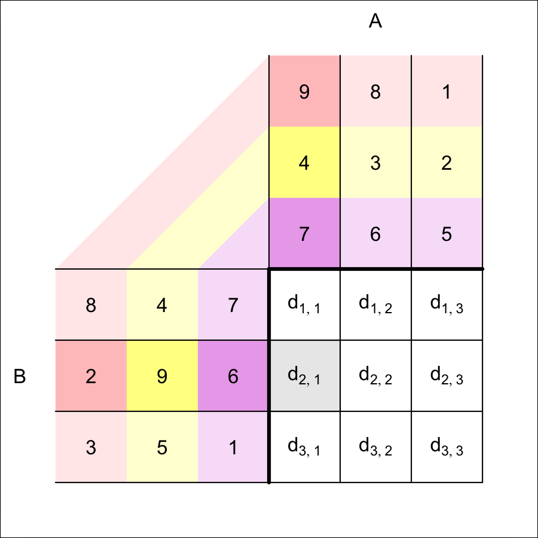

Notice we use row 2 from $B$ and column 1 from $A$.

$$d_{2,1}~~=~~2\cdot 9~+~9\cdot 4~+~6\cdot
7$$
$$d_{2,1}~~=~~96$$

Let matrices $A$ and $B$ be defined below.

$$A = \begin{bmatrix}
4 & 1 & 7\\
9 & 6 & 8\\
2 & 3 & 5
\end{bmatrix}$$
$$B = \begin{bmatrix}
4 & 6 & 2\\
8 & 7 & 9\\
5 & 3 & 1
\end{bmatrix}$$

Also, let $C=AB$ and $D=BA$.

- Find element $c_{2,1}$

I'd recommend setting up a diagram on (*gasp*) paper.

When calculating matrix $C$ with the matrix multiplication $C=A\cdot B$, the fact that matrix $A$ is before matrix $B$ matters (because matrix multiplication is **NOT** [commutative](https://en.wikipedia.org/wiki/Commutative_property)). So, in our diagram, matrix $A$ is in bottom-left position and matrix $B$ is in top-right position.

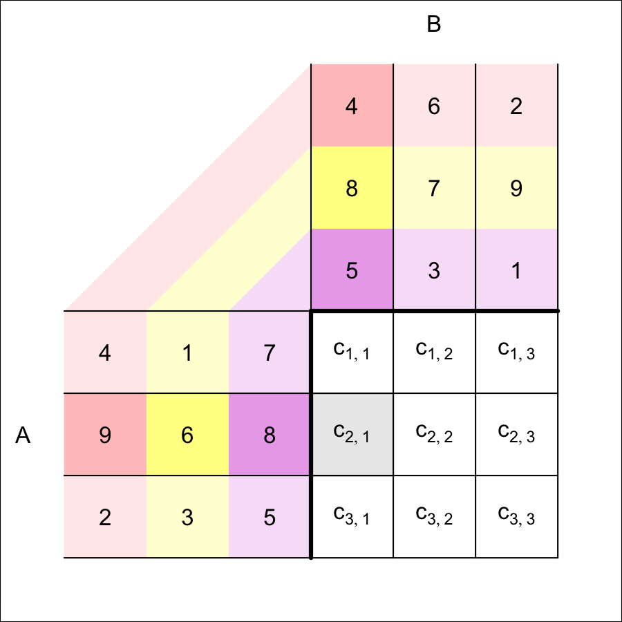

Notice we use row 2 from $A$ and column 1 from $B$.

$$c_{2,1}~~=~~9\cdot 4~+~6\cdot 8~+~8\cdot
5$$
$$c_{2,1}~~=~~124$$

Let matrices $A$ and $B$ be defined below.

$$A = \begin{bmatrix}
8 & 6 & 5\\
9 & 7 & 1\\
4 & 3 & 2
\end{bmatrix}$$
$$B = \begin{bmatrix}
2 & 5 & 6\\
8 & 3 & 4\\
7 & 9 & 1
\end{bmatrix}$$

Also, let $C=AB$ and $D=BA$.

- Find element $c_{1,2}$

I'd recommend setting up a diagram on (*gasp*) paper.

When calculating matrix $C$ with the matrix multiplication $C=A\cdot B$, the fact that matrix $A$ is before matrix $B$ matters (because matrix multiplication is **NOT** [commutative](https://en.wikipedia.org/wiki/Commutative_property)). So, in our diagram, matrix $A$ is in bottom-left position and matrix $B$ is in top-right position.

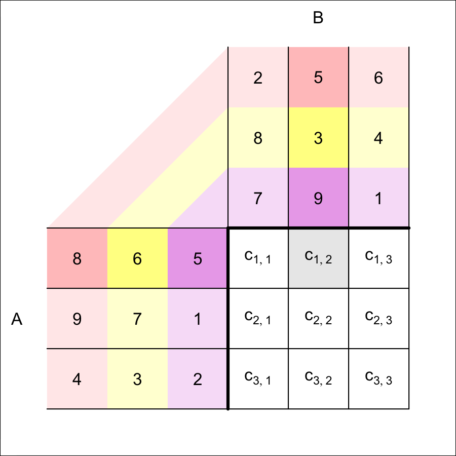

Notice we use row 1 from $A$ and column 2 from $B$.

$$c_{1,2}~~=~~8\cdot 5~+~6\cdot 3~+~5\cdot
9$$
$$c_{1,2}~~=~~103$$

Let matrices $A$ and $B$ be defined below.

$$A = \begin{bmatrix}
3 & 2 & 6\\
4 & 7 & 1\\
5 & 8 & 9
\end{bmatrix}$$
$$B = \begin{bmatrix}
4 & 6 & 1\\
9 & 2 & 5\\
8 & 7 & 3
\end{bmatrix}$$

Also, let $C=AB$ and $D=BA$.

- Find element $c_{1,2}$

I'd recommend setting up a diagram on (*gasp*) paper.

When calculating matrix $C$ with the matrix multiplication $C=A\cdot B$, the fact that matrix $A$ is before matrix $B$ matters (because matrix multiplication is **NOT** [commutative](https://en.wikipedia.org/wiki/Commutative_property)). So, in our diagram, matrix $A$ is in bottom-left position and matrix $B$ is in top-right position.

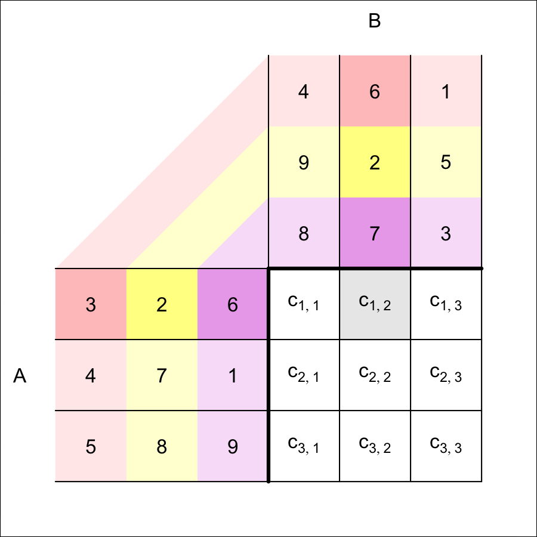

Notice we use row 1 from $A$ and column 2 from $B$.

$$c_{1,2}~~=~~3\cdot 6~+~2\cdot 2~+~6\cdot
7$$
$$c_{1,2}~~=~~64$$

Let matrices $A$ and $B$ be defined below.

$$A = \begin{bmatrix}
2 & 7 & 6\\
8 & 1 & 9\\
3 & 4 & 5
\end{bmatrix}$$
$$B = \begin{bmatrix}
6 & 1 & 2\\
7 & 8 & 4\\
9 & 5 & 3
\end{bmatrix}$$

Also, let $C=AB$ and $D=BA$.

- Find element $c_{2,3}$

I'd recommend setting up a diagram on (*gasp*) paper.

When calculating matrix $C$ with the matrix multiplication $C=A\cdot B$, the fact that matrix $A$ is before matrix $B$ matters (because matrix multiplication is **NOT** [commutative](https://en.wikipedia.org/wiki/Commutative_property)). So, in our diagram, matrix $A$ is in bottom-left position and matrix $B$ is in top-right position.

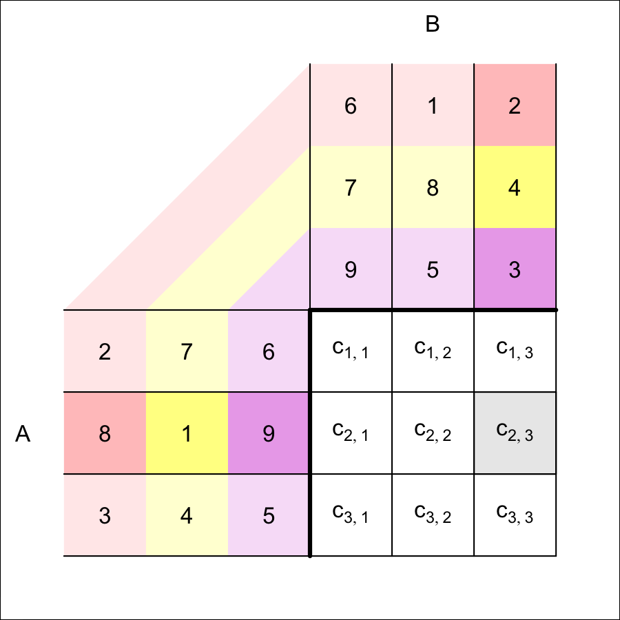

Notice we use row 2 from $A$ and column 3 from $B$.

$$c_{2,3}~~=~~8\cdot 2~+~1\cdot 4~+~9\cdot
3$$
$$c_{2,3}~~=~~47$$

Let matrices $A$ and $B$ be defined below.

$$A = \begin{bmatrix}
3 & 2 & 1\\
9 & 4 & 6\\
8 & 5 & 7
\end{bmatrix}$$
$$B = \begin{bmatrix}
5 & 6 & 8\\
9 & 7 & 3\\
4 & 1 & 2
\end{bmatrix}$$

Also, let $C=AB$ and $D=BA$.

- Find element $d_{2,3}$

I'd recommend setting up a diagram on (*gasp*) paper.

When calculating matrix $D$ with the matrix multiplication $D=B\cdot A$, the fact that matrix $B$ is before matrix $A$ matters (because matrix multiplication is **NOT** [commutative](https://en.wikipedia.org/wiki/Commutative_property)). So, in our diagram, matrix $B$ is in bottom-left position and matrix $A$ is in top-right position.

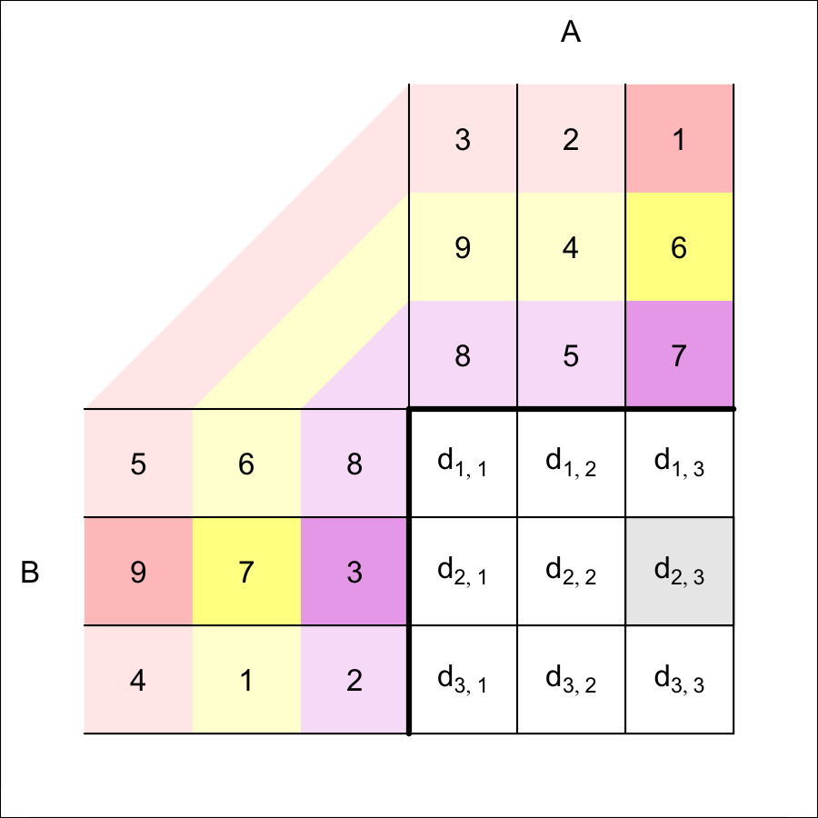

Notice we use row 2 from $B$ and column 3 from $A$.

$$d_{2,3}~~=~~9\cdot 1~+~7\cdot 6~+~3\cdot
7$$
$$d_{2,3}~~=~~72$$

Let matrices $A$ and $B$ be defined below.

$$A = \begin{bmatrix}
8 & 9 & 7\\
6 & 5 & 3\\
1 & 2 & 4
\end{bmatrix}$$
$$B = \begin{bmatrix}
8 & 6 & 2\\
5 & 9 & 3\\
1 & 4 & 7
\end{bmatrix}$$

Also, let $C=AB$ and $D=BA$.

- Find element $c_{3,1}$

I'd recommend setting up a diagram on (*gasp*) paper.

When calculating matrix $C$ with the matrix multiplication $C=A\cdot B$, the fact that matrix $A$ is before matrix $B$ matters (because matrix multiplication is **NOT** [commutative](https://en.wikipedia.org/wiki/Commutative_property)). So, in our diagram, matrix $A$ is in bottom-left position and matrix $B$ is in top-right position.

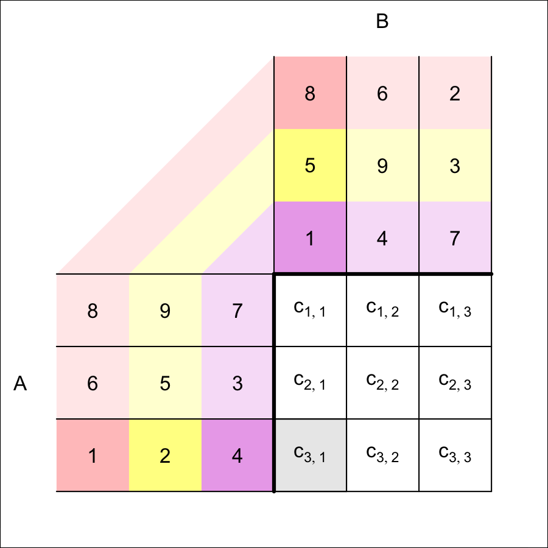

Notice we use row 3 from $A$ and column 1 from $B$.

$$c_{3,1}~~=~~1\cdot 8~+~2\cdot 5~+~4\cdot
1$$
$$c_{3,1}~~=~~22$$

Let matrices $A$ and $B$ be defined below.

$$A = \begin{bmatrix}
8 & 3 & 7\\
2 & 6 & 1\\
5 & 9 & 4
\end{bmatrix}$$
$$B = \begin{bmatrix}
5 & 6 & 3\\
1 & 7 & 4\\
2 & 9 & 8
\end{bmatrix}$$

Also, let $C=AB$ and $D=BA$.

- Find element $d_{2,3}$

I'd recommend setting up a diagram on (*gasp*) paper.

When calculating matrix $D$ with the matrix multiplication $D=B\cdot A$, the fact that matrix $B$ is before matrix $A$ matters (because matrix multiplication is **NOT** [commutative](https://en.wikipedia.org/wiki/Commutative_property)). So, in our diagram, matrix $B$ is in bottom-left position and matrix $A$ is in top-right position.

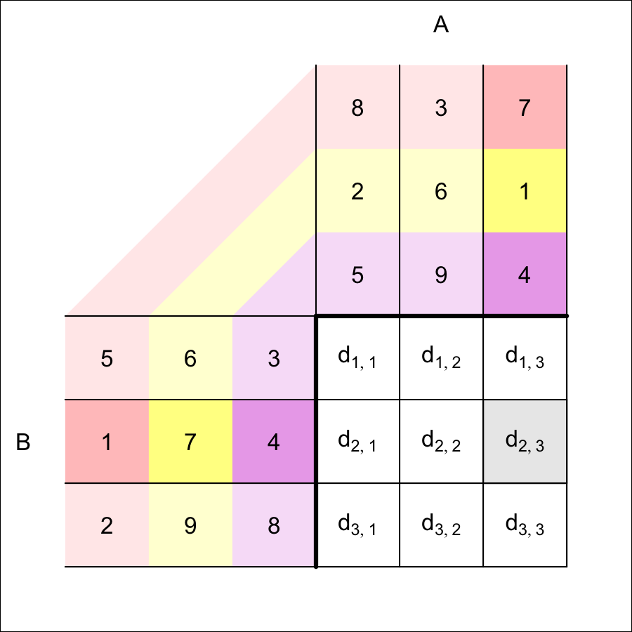

Notice we use row 2 from $B$ and column 3 from $A$.

$$d_{2,3}~~=~~1\cdot 7~+~7\cdot 1~+~4\cdot
4$$
$$d_{2,3}~~=~~30$$

Let matrices $A$ and $B$ be defined below.

$$A = \begin{bmatrix}
6 & 2 & 1\\
7 & 8 & 4\\
5 & 9 & 3
\end{bmatrix}$$
$$B = \begin{bmatrix}
1 & 6 & 2\\
8 & 5 & 9\\
4 & 7 & 3
\end{bmatrix}$$

Also, let $C=AB$ and $D=BA$.

- Find element $c_{1,3}$

I'd recommend setting up a diagram on (*gasp*) paper.

When calculating matrix $C$ with the matrix multiplication $C=A\cdot B$, the fact that matrix $A$ is before matrix $B$ matters (because matrix multiplication is **NOT** [commutative](https://en.wikipedia.org/wiki/Commutative_property)). So, in our diagram, matrix $A$ is in bottom-left position and matrix $B$ is in top-right position.

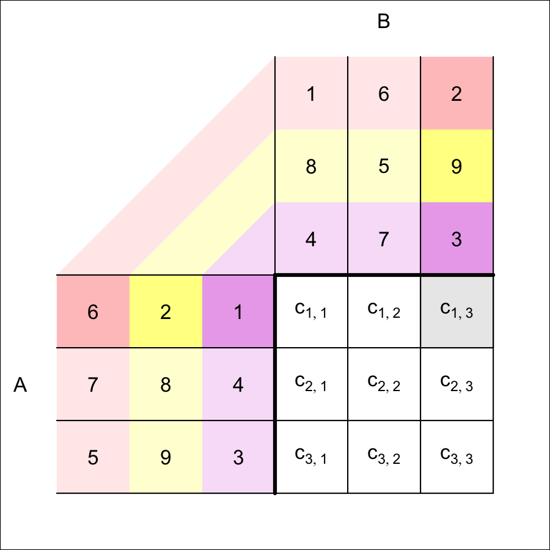

Notice we use row 1 from $A$ and column 3 from $B$.

$$c_{1,3}~~=~~6\cdot 2~+~2\cdot 9~+~1\cdot
3$$
$$c_{1,3}~~=~~33$$

Let matrices $A$ and $B$ be defined below.

$$A = \begin{bmatrix}
9 & 7 & 4\\
8 & 5 & 6\\
1 & 2 & 3
\end{bmatrix}$$
$$B = \begin{bmatrix}
5 & 7 & 6\\
1 & 3 & 9\\
2 & 4 & 8
\end{bmatrix}$$

Also, let $C=AB$ and $D=BA$.

- Find element $d_{2,3}$

I'd recommend setting up a diagram on (*gasp*) paper.

When calculating matrix $D$ with the matrix multiplication $D=B\cdot A$, the fact that matrix $B$ is before matrix $A$ matters (because matrix multiplication is **NOT** [commutative](https://en.wikipedia.org/wiki/Commutative_property)). So, in our diagram, matrix $B$ is in bottom-left position and matrix $A$ is in top-right position.

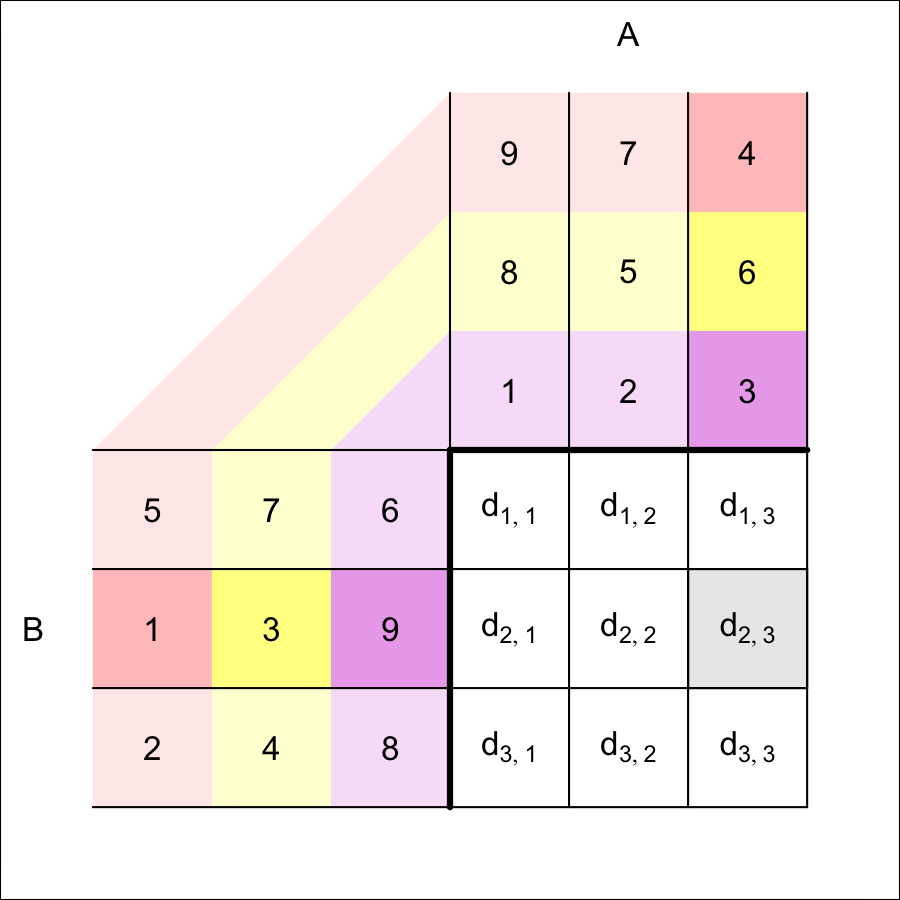

Notice we use row 2 from $B$ and column 3 from $A$.

$$d_{2,3}~~=~~1\cdot 4~+~3\cdot 6~+~9\cdot
3$$
$$d_{2,3}~~=~~49$$